# Clase 5 - Visualizando información geográfica

Diplomatura en Ciencias Sociales Computacionales y Humanidades Digitales - UNSAM

Seminario de Visualización de datos en R

Florencia Piñeyrúa y Nayla Sol Garcilazo

## Información geográfica y mapas

Durante el siglo pasado, los labores de producción de mapas y análisis espacial estaban reservadas para especialistas, debido a la complejidad de las tareas y al alto costo de producción y adquisición de datos geográficos. Sin embargo, durante las dos últimas décadas la tecnología digital cambió el panorama.

Una dramática caída en el costo asociado a adquirir y procesar información geográfica (pensemos en satélites y computadoras multiplicándose y bajando de precio) dio paso al mapa digital como herramienta universal. El consumo de sofisticados mapas y otros productos geográficos se volvió masivo y cotidiano, con Google Maps como el exponente más conocido. Apenas había pasado la novedad de disponer de mapas en alta resolución de todo el mundo accesibles al instante desde nuestros escritorios, cuando la llegada de los *smartphones* popularizó el acceso en cualquier momento y lugar.

El mismo proceso que nos convirtió a todos en consumidores constantes de información geográfica también nos da la oportunidad de ser los productores. Sin dudas, hacer mapas se ha vuelto más fácil que en el pasado. Existen cada vez más repositorios con información georreferenciada de acceso publico -datasets que incluyen información precisa sobre su ubicación geográfica. Al mismo tiempo, maduran y se hacen más fáciles de usar las herramientas para análisis y visualización espacial.

En los procesos sociales, el “dónde” suele ser un aspecto clave. Es central para quienes estudiamos -por ejemplo- las ciudades o las dinámicas de la política, siempre tan arraigadas a lo territorial. Esto vuelve al mapa una de las herramientas de visualización más importantes que podemos emplear.

En R contamos con varios paquete de funciones que permiten manipular información espacial con facilidad. A continuación vamos a aprender a combinarlos con las herramientas que ya hemos aprendido para hacer análisis geográfico y crear nuestros propios mapas.

### Geometrías

Los archivos de datos geográficos relacionados con fenómenos sociales (datos de cosas que somos y hacemos los humanos, como composición de población, trazado de rutas o ubicación de hospitales) suelen ser de tipo vectorial. Los datos vectoriales expresan la posición y extensión de cosas mediante geometrías, que pueden ser de puntos, de líneas, o de polígonos. En la jerga de los sistemas de información geográfica se les llama “capas” (*layers*) a los archivos que contienen estas geometrías; en ese sentido, se habla de combinar capas para crear mapas.

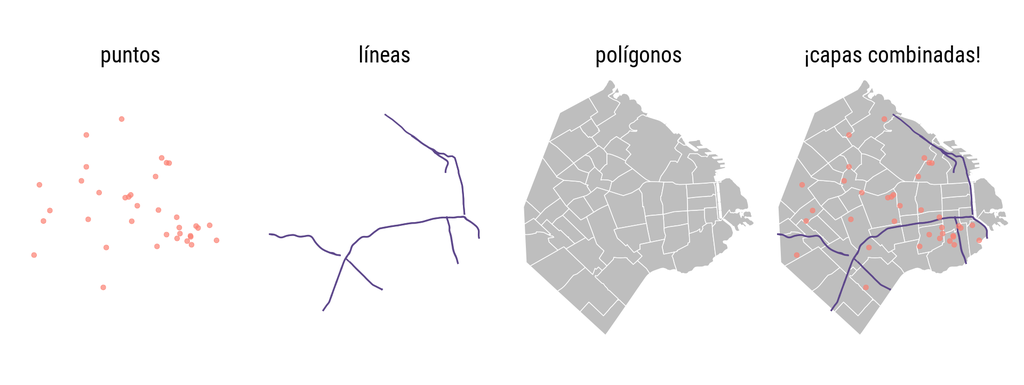

- Un archivo geográfico con geometría de **puntos** se utiliza para marcar **posiciones**: por ejemplo, puntos que señalen la ubicación de hospitales.
- La geometría de **líneas** permite mostrar **recorridos**: la extensión de ríos, de autopistas o de calles, son ejemplos típicos.
- Los **polígonos** se usan cuando hay que representar **superficies**: el territorio de barrios, provincias o países; el terreno ocupado por parques y plazas, la extensión de parcelas o los límites de áreas especiales.

### ¿Cuánto detalle queremos en un mapa?

Cuando trabajamos con información geográfica, una de las primeras decisiones conceptuales es el nivel detalle. No es lo mismo un mapa como “foto del mundo” (una imagen satelital) que un mapa de calles y avenidas, y tampoco es lo mismo representar una ciudad con sus radios censales que con un esquema abstracto de barrios.

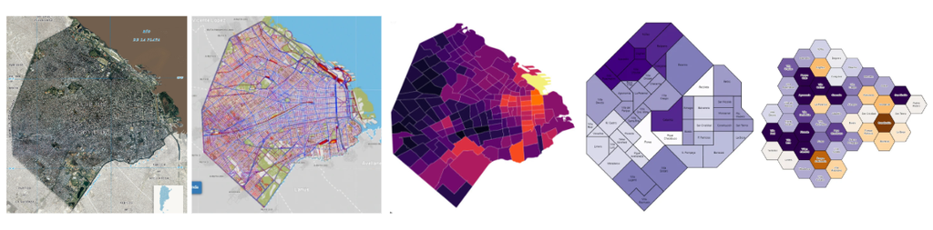

### Los datos georreferenciados

El atributo que distingue a los datos georreferenciados, lo que los hace merecer ese nombre, es que representan ubicaciones exactas sobre la superficie de la Tierra. Representar en forma precisa una posición sobre la superficie terrestre es un todo un reto. Para empezar, la Tierra tiene una forma irregular. A pesar de cómo solemos imaginarla y dibujarla, no es una esfera perfecta sino que está “achatada” en los polos, dificultando la matemática necesaria para comparar posiciones y medir distancias. Luego, está el problema de cómo mostrar sobre papel impreso, o en una pantalla digital, -superficies planas- rasgos geográficos que pertenecen a una superficie tridimensional esférica. La solución a estos problemas toma la forma de sistemas de coordenadas de referencia (*CRS* por sus siglas en inglés) y de proyecciones cartográficas.

Los CRS son un sistema de números que definen ubicaciones sobre la superficie de la Tierra; funcionan como direcciones. El tipo de CRS más conocido es el que usa latitud y longitud para definir posiciones en los ejes norte-sur y este-oeste.

Las proyecciones cartográficas son instrucciones para traducir a un plano la disposición de puntos ubicados en la esfera terrestre. Algo así como las instrucciones para dibujar en dos dimensiones las disposición de fronteras, accidentes geográficos, calles o cualquier otro objeto que se extiende sobre la superficie curva del planeta. Como en toda traducción, hay algo que se pierde en el proceso. Todo los mapas “mienten”, en el sentido en que presentan una versión distorsionada de la superficie de terrestre. Esto es inevitable; no existe forma de pasar de la esfera al plano sin distorsionar la forma, la superficie, la distancia o la dirección de los rasgo geográficos. Existen muchísimas proyecciones distintas, cada una pensada para minimizar alguno de los tipos de distorsión o para encontrar una solución de compromiso que los balancee.

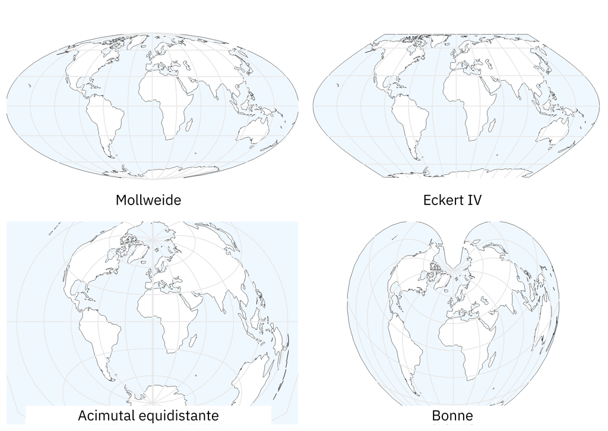

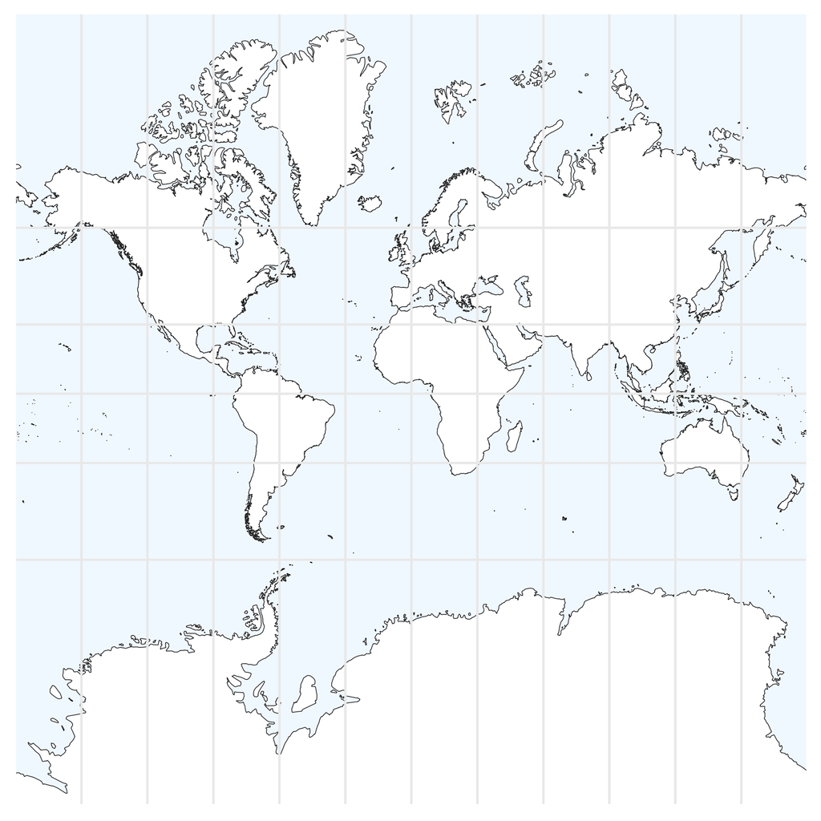

En la práctica, si trabajamos en forma frecuente con archivos georreferenciados vamos a sufrir tarde o temprano de problemas de coordenadas o proyección. El más común de ellos: tener una fuentes de datos geográficos que no podemos comparar con otras, porque desconocemos el sistema de coordenadas que se usó para crearla; es decir, no podemos saber a que posición sobre el planeta corresponde cada observación en los datos.

### Accediendo a datos geográficos

¿Qué datos tenemos?

[figure not shown]

Otro problema asociado a trabajar con datos geográficos es el de los formatos de archivo. El formato más común es el denominado “shapefile”, inventado por la empresa ESRI (los creadores del software ArcGIS). Es un formato incómodo porque guarda la información en varios archivos distintos, que suelen ser combinados en un archivo .zip para su distribución. Un inconveniente aún mayor es que los nombres de las variables en un shapefile deben tener 10 caracteres o menos, lo que facilita el uso de abreviaturas ininteligibles. A pesar de éstos y otros detrimentos, el formato es tan común que se ha vuelto sinónimo de archivo con información geográfica, y resiste a pesar de los esfuerzos por reemplazarlo con alternativas más modernas. Una de ellas es “GeoJSON”, un estándar abierto que corrige los dos inconvenientes mencionados antes. Para nuestros ejercicios usaremos datos geográficos en esta último formato.

Vamos a trabajar, como siempre con `ggplot2`. Y ahora también sumamos el paquete [`sf`](https://r-spatial.github.io/sf/), que brinda funciones para trabajar con datos georefrenciados.

```r
library(ggplot2)
library(sf)
```

Practicaremos con datos georeferenciados en polígonos: el territorio de la Ciudad de Buenos Aires dividido en radios censales, la unidad geográfica más pequeña para la que se dispone de datos públicos producidos por el censo nacional.

Podemos leemos el archivo con datos geográficos directo desde internet:

```r
radios <- read_sf("https://bitsandbricks.github.io/data/CABA_rc.geojson")
```

Como con cualquier otro dataset, podemos escribir su nombre de variable y ejecutar la línea para ver el contenido:

```r
head(radios)
```

```
## Simple feature collection with 6 features and 8 fields
## Geometry type: MULTIPOLYGON
## Dimension:     XY
## Bounding box:  xmin: -58.38593 ymin: -34.60846 xmax: -58.35054 ymax: -34.57865
## Geodetic CRS:  WGS 84
##   RADIO_ID      BARRIO COMUNA POBLACION VIVIENDAS HOGARES HOGARES_NBI
## 1    1_1_1      RETIRO      1       336        82      65          19
## 2   1_12_1 SAN NICOLAS      1       341       365     116          25
## 3  1_12_10 SAN NICOLAS      1       296       629     101           1
## 4  1_12_11 SAN NICOLAS      1       528       375     136           7
## 5   1_12_2 SAN NICOLAS      1       229       445     129          16
## 6   1_12_3 SAN NICOLAS      1       723       744     314         104
##     AREA_KM2                       geometry
## 1 1.79899705 MULTIPOLYGON (((-58.37189 -...
## 2 0.01856469 MULTIPOLYGON (((-58.38593 -...
## 3 0.04438025 MULTIPOLYGON (((-58.37879 -...
## 4 0.36634000 MULTIPOLYGON (((-58.36733 -...
## 5 0.01836301 MULTIPOLYGON (((-58.38454 -...
## 6 0.03672540 MULTIPOLYGON (((-58.38154 -...
```

- “RADIO_ID” es el código que identifica cada radio censal.
- “BARRIO” y “COMUNA” representan barrio y comuna de cada radio (vaya sorpresa!).
- “POBLACION” indica la cantidad de habitantes del radio, según Censo 2010.
- “HOGARES_NBI” representa la cantidad de hogares donde se encontró que al menos una de sus necesidades básicas insatisfechas.
- “AREA_KM2” indica la superficie.
- y por último queda la columna `geometry`, que contiene una serie de puntos que permiten trazar la silueta de cada radio (sus polígonos). Nosotros no vamos a prestarle atención, pero para R es fundamental, ya que le permite proyectar mapas y hacer cálculos geométricos cuando se lo pidamos.

Ahora, ¿cómo podemos ver el sistema de coordenadas de nuestros datos?

```r
st_crs(radios)
```

```
## Coordinate Reference System:
##   User input: WGS 84
##   wkt:
## GEOGCRS["WGS 84",
##     DATUM["World Geodetic System 1984",
##         ELLIPSOID["WGS 84",6378137,298.257223563,
##             LENGTHUNIT["metre",1]]],
##     PRIMEM["Greenwich",0,
##         ANGLEUNIT["degree",0.0174532925199433]],
##     CS[ellipsoidal,2],
##         AXIS["geodetic latitude (Lat)",north,
##             ORDER[1],
##             ANGLEUNIT["degree",0.0174532925199433]],
##         AXIS["geodetic longitude (Lon)",east,
##             ORDER[2],
##             ANGLEUNIT["degree",0.0174532925199433]],
##     ID["EPSG",4326]]
```

```r
radios_mercator <- st_transform(radios, 3857)
st_crs(radios_mercator)
```

```
## Coordinate Reference System:
##   User input: EPSG:3857
##   wkt:
## PROJCRS["WGS 84 / Pseudo-Mercator",
##     BASEGEOGCRS["WGS 84",
##         ENSEMBLE["World Geodetic System 1984 ensemble",
##             MEMBER["World Geodetic System 1984 (Transit)"],
##             MEMBER["World Geodetic System 1984 (G730)"],
##             MEMBER["World Geodetic System 1984 (G873)"],
##             MEMBER["World Geodetic System 1984 (G1150)"],
##             MEMBER["World Geodetic System 1984 (G1674)"],
##             MEMBER["World Geodetic System 1984 (G1762)"],
##             MEMBER["World Geodetic System 1984 (G2139)"],
##             ELLIPSOID["WGS 84",6378137,298.257223563,
##                 LENGTHUNIT["metre",1]],
##             ENSEMBLEACCURACY[2.0]],
##         PRIMEM["Greenwich",0,
##             ANGLEUNIT["degree",0.0174532925199433]],
##         ID["EPSG",4326]],
##     CONVERSION["Popular Visualisation Pseudo-Mercator",
##         METHOD["Popular Visualisation Pseudo Mercator",
##             ID["EPSG",1024]],
##         PARAMETER["Latitude of natural origin",0,
##             ANGLEUNIT["degree",0.0174532925199433],
##             ID["EPSG",8801]],
##         PARAMETER["Longitude of natural origin",0,
##             ANGLEUNIT["degree",0.0174532925199433],
##             ID["EPSG",8802]],
##         PARAMETER["False easting",0,
##             LENGTHUNIT["metre",1],
##             ID["EPSG",8806]],
##         PARAMETER["False northing",0,
##             LENGTHUNIT["metre",1],
##             ID["EPSG",8807]]],
##     CS[Cartesian,2],
##         AXIS["easting (X)",east,
##             ORDER[1],
##             LENGTHUNIT["metre",1]],
##         AXIS["northing (Y)",north,
##             ORDER[2],
##             LENGTHUNIT["metre",1]],
##     USAGE[
##         SCOPE["Web mapping and visualisation."],
##         AREA["World between 85.06°S and 85.06°N."],
##         BBOX[-85.06,-180,85.06,180]],
##     ID["EPSG",3857]]
```

Ahora, a generar mapas.

## Visualizando información geográfica

La visualización de información geográfica por excelencia es el mapa… ¡por supuesto!

`ggplot()` puede graficar datos geográficos empleando la geometría `geom_sf()`. Probemos:

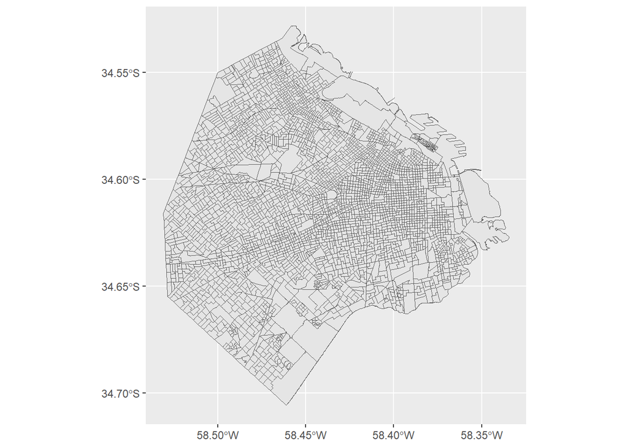

```r
ggplot(radios) +
  geom_sf()
```

Ahora usemos el atributo estético “fill” para pintar el interior de cada polígono de acuerdo a la cantidad de gente que vive allí (variable “POBLACION”):

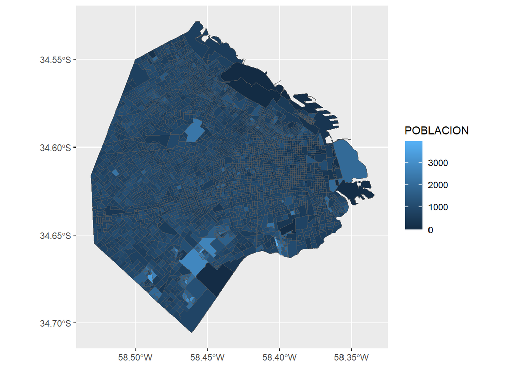

```r
ggplot(radios) +
  geom_sf(aes(fill = POBLACION))
```

Continuemos puliendo el gráfico. Cuando pintamos polígonos para mostrar datos, el grosor de la línea que traza las fronteras a veces hace difícil determinar el color de relleno. Esto suele pasar cuando se muestra información geográfica intrincada como la de los radios censales. Una solución es definir el color de la línea como `NA`, que para `ggplot` significa “ninguno”. Como siempre que queremos modificar un atributo estético en forma arbitraria -un valor fijo, que no dependa de los datos- debemos hacerlo por fuera de `aes()`:

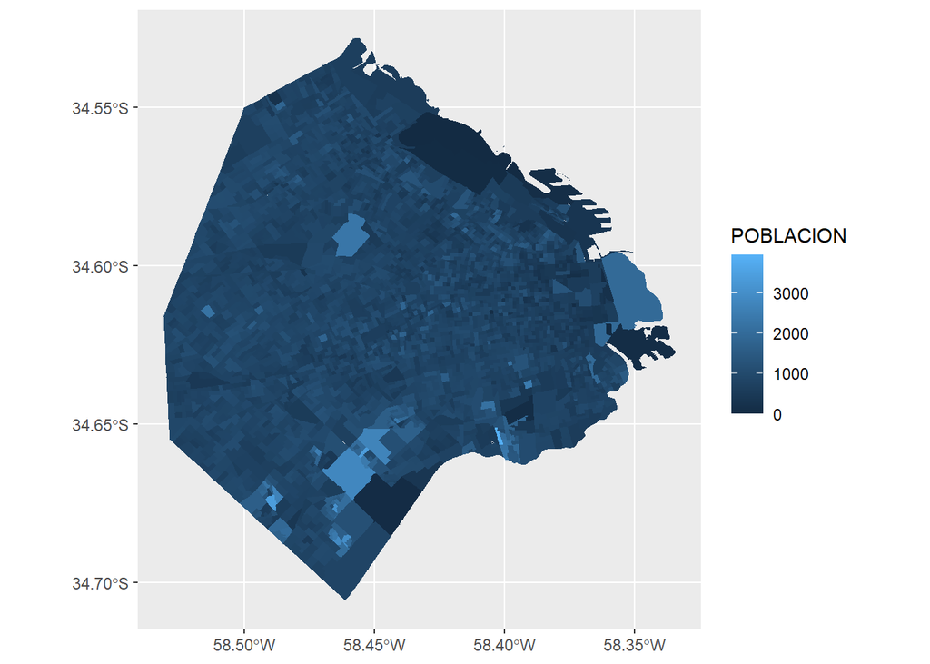

```r
ggplot(radios) +
  geom_sf(aes(fill = POBLACION), color = NA)
```

Así esta mejor.

Algo importante que no hemos mencionado aún es la importancia de “normalizar” las variables antes de mostrarlas en un mapa.

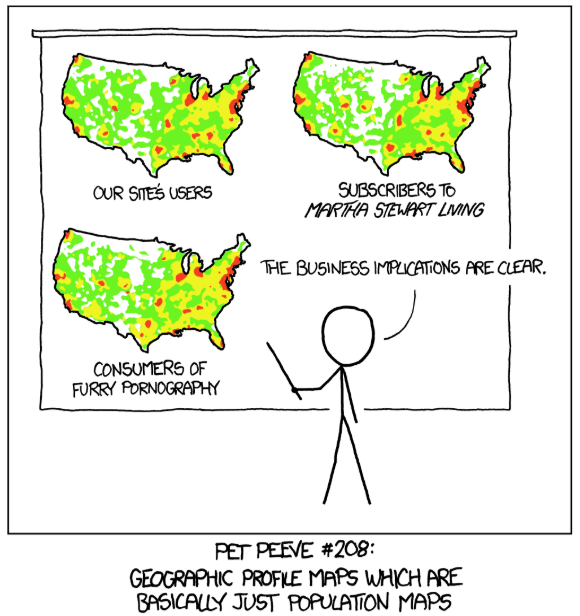

En general, los lugares más grandes van a contener dentro “más” de cualquier variable que los lugares pequeños (sean personas, comercios o accidentes). Es de esperarse que en el barrio más pequeño de la ciudad vivan menos personas que en el más grande; lo que es útil saber es si los valores son bajo o altos para un área *con esa extensión*. Ejemplos típicos:

- En lugar de mostrar “número de crímenes por barrio” es más instructivo mostrar el número de crímenes per cápita; de lo contrario es de esperar que los lugares más poblados siempre registren más incidentes, lo cual no agrega demasiada información.
- En lugar de mostrar “cantidad de habitantes por radio censal”, mostramos la densidad de población, es decir la cantidad de habitantes dividida por la extensión del área. Los mapas de densidad muestran mucho mejor la distribución espacial de la población.

Con nuestros datos, podemos visualizar la densidad de la población mostrando la cantidad de habitantes dividida por la superficie del polígono. O sea, POBLACION / AREA_KM2:

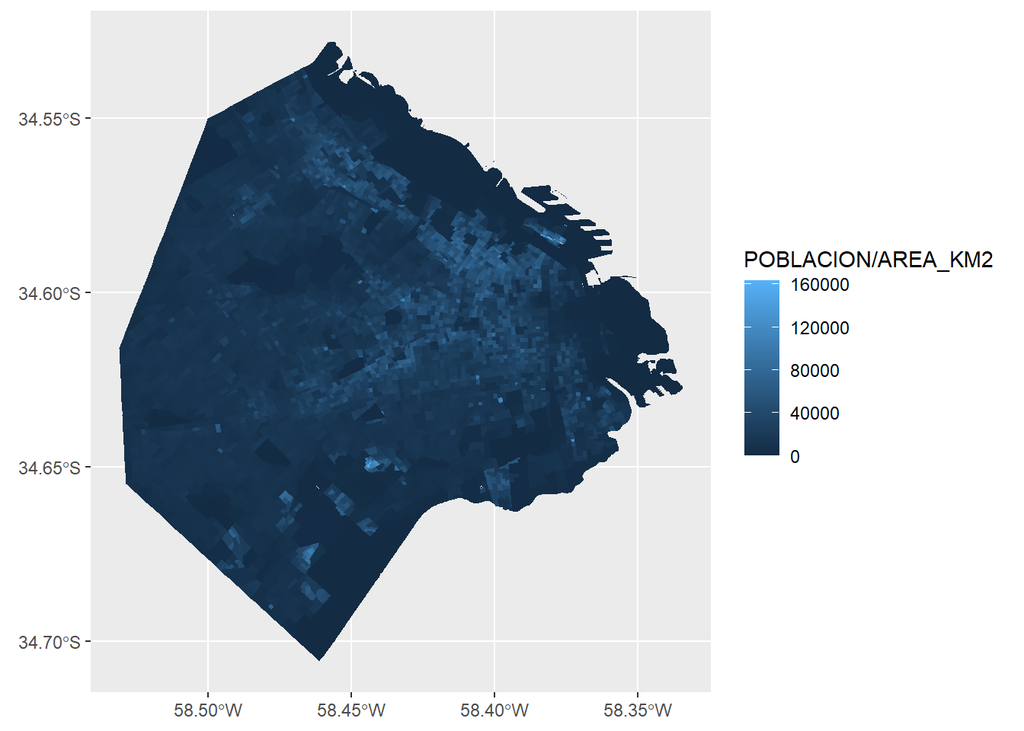

```r
ggplot(radios) +
  geom_sf(aes(fill = POBLACION/AREA_KM2), color = NA)
```

Este último gráfico representa de forma mucho mas precisa la distribución de habitantes en la ciudad, haciendo saltar a la vista los núcleos con mayor densidad de población. Pero tenemos una mejora más por realizar: elegir una escala de color que haga más legible el gráfico, ayudando al ojo a diferenciar las áreas donde la densidad es particularmente alta o baja. Apelamos a [“viridis”](https://cran.r-project.org/web/packages/viridis/vignettes/intro-to-viridis.html), una escala diseñada para ser fácil de interpretar… y lucir bien de paso. Para usar virids, agregamos `scale_fill_viridis_d()` cuando se muestra una variable categórica, y `scale_fill_viridis_c()`cuando se trata de una variable continua, nuestro caso en este momento.

¿Cómo queda con la escala viridis?

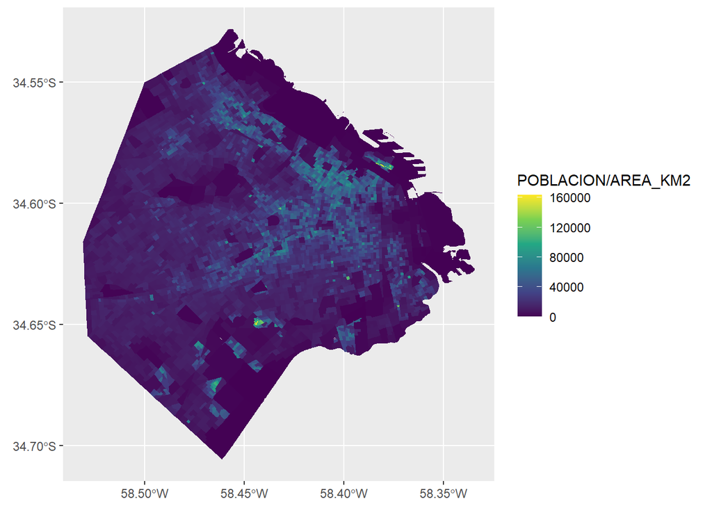

```r
ggplot() +
  geom_sf(data = radios, aes(fill = POBLACION/AREA_KM2), color = NA) +
  scale_fill_viridis_c()
```

Si vamos a compartir este gráfico, necesitamos agregar un título descriptivo, definir nombres claros para las leyendas, etc. Además, podemos elegir un tema que resulte adecuado para mostrar datos geográficos. Dos opciones disponibles son `theme_minimal()`, que ya hemos probado, y `theme_void()`. Probemos usando uno u otro. ¿Cuál es la diferencia?

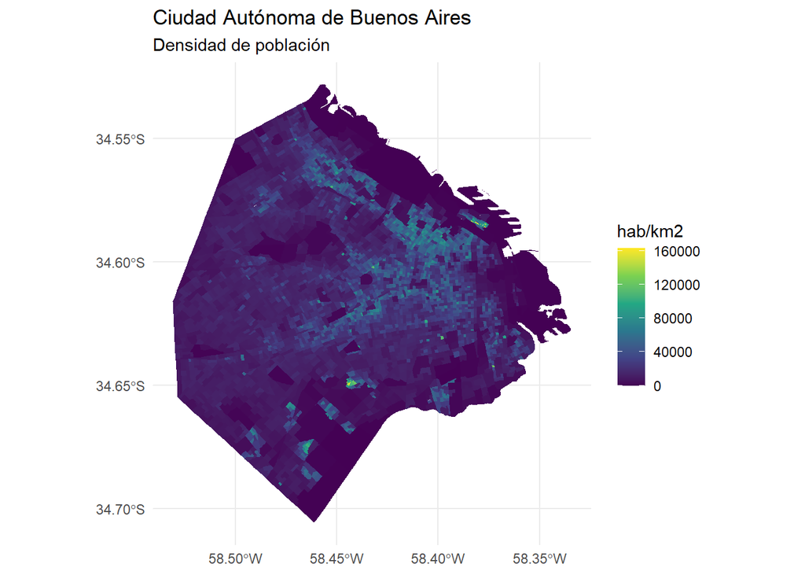

```r
ggplot() +
  geom_sf(data = radios, aes(fill = POBLACION/AREA_KM2), color = NA) +
  scale_fill_viridis_c() +
  labs(title = "Ciudad Autónoma de Buenos Aires",
       subtitle = "Densidad de población",
       fill = "hab/km2") +
  theme_minimal()
```

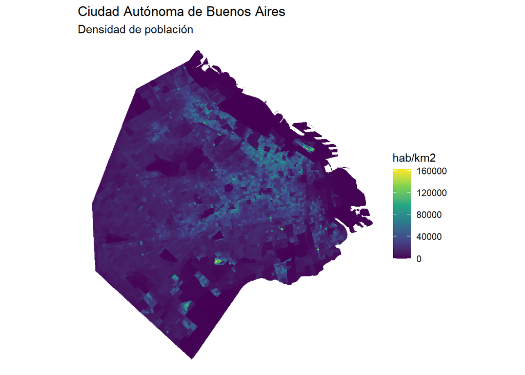

```r
ggplot() +
  geom_sf(data = radios, aes(fill = POBLACION/AREA_KM2), color = NA) +
  scale_fill_viridis_c() +
  labs(title = "Ciudad Autónoma de Buenos Aires",
       subtitle = "Densidad de población",
       fill = "hab/km2") +
    theme_void()
```

## Volcando en el mapa múltiples capas de información

En algunos casos, un archivo con información geográfica contiene todos los datos que necesitamos. Pero lo habitual es que el archivo sólo brinde la ubicación y fronteras de nuestras unidades de análisis, de manera que necesitamos agregarle los datos que hemos obtenido de otras fuentes y queremos proyectar en un mapa.

Comentamos al principio de la clase que los archivos con datos espaciales pueden representar áreas (polígonos), líneas o puntos. Hasta ahora hemos hecho mapas con polígonos, pero según el caso podríamos querer mostrar otros tipos de geometría.

Un ámbito donde es común utilizar toda la variedad de geometrías es el transporte: polígonos para representar distritos, líneas para el recorrido de un sistema de transporte y puntos para la ubicación de las estaciones.

Sumemos a nuestra colección datos espaciales con

- las líneas de transporte subterráneo (SUBTE) de la ciudad

```r
subte_lineas <- read_sf("http://bitsandbricks.github.io/data/subte_lineas.geojson")
```

[output not shown]

- y los puntos con las ubicaciones de las estaciones de SUBTE

```r
subte_estaciones <- read_sf("http://bitsandbricks.github.io/data/subte_estaciones.geojson")
```

[output not shown]

Combinar capas mostrado distintas geometrías es simple. Sólo es cuestión de sumar capas de `geom_sf()` asignando a cada una un dataframe espacial a mostrar con el parámetro “data”; por ejemplo, `data = radios`. Mostremos los radios censales (`data = radios`) y el trazado de las líneas de transporte (`data = subte_lineas`) en el mismo mapa:

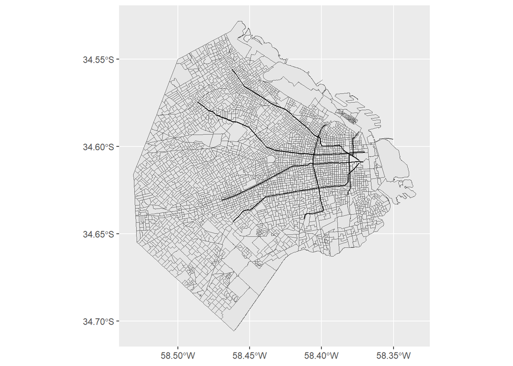

```r
ggplot() +
    geom_sf(data = radios) +
    geom_sf(data = subte_lineas)
```

Y del mismo modo, sumemos una capa más para mostrar la ubicación de las estaciones (`data = subte_estaciones`):

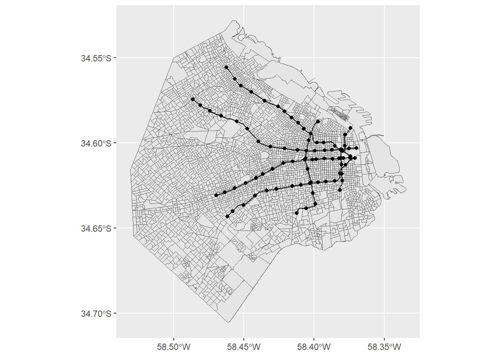

```r
ggplot() +
    geom_sf(data = radios) +
    geom_sf(data = subte_lineas) +
    geom_sf(data = subte_estaciones)
```

### Síntesis y costos de la abstracción

Aquí aparece un ejemplo clásico del dilema de capas múltiples. El mapa esquemático del subte no intenta ser topográficamente fiel, sino funcionalmente inteligible. Permite ver en qué momentos las líneas viajan juntas, dónde están los extremos y cómo combinar recorridos. Esa claridad tiene un costo: puede hacernos creer que dos estaciones están próximas cuando en el territorio físico no lo están.

[figure not shown]

### Incorporando color a nuestros mapas

Mostremos cada línea con un color distinto, en base a la variable “LINEA”. Y hagamos lo mismo para la capa de estaciones.

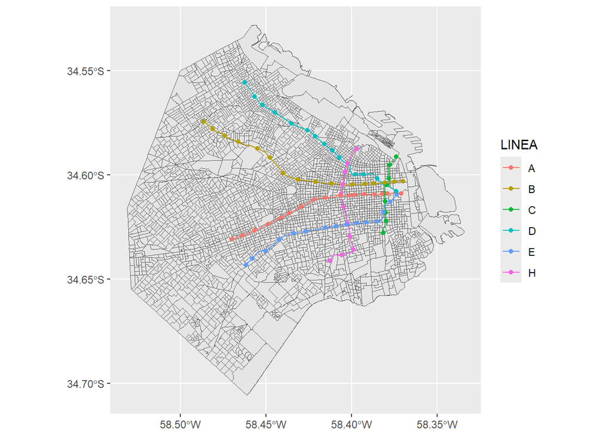

```r
ggplot() +
    geom_sf(data = radios) +
    geom_sf(data = subte_lineas, aes(color = LINEA)) +
    geom_sf(data = subte_estaciones, aes(color = LINEA))
```

¡Funciona! Eso si, el gráfico queda bastante recargado por la abundancia de líneas. Podemos mostrar sólo la extensión de la ciudad, sin detalle interno, para resaltar las líneas de transporte. Como hicmos antes, podemos hacer desaparecer la división entre polígonos usando `color = NA`:

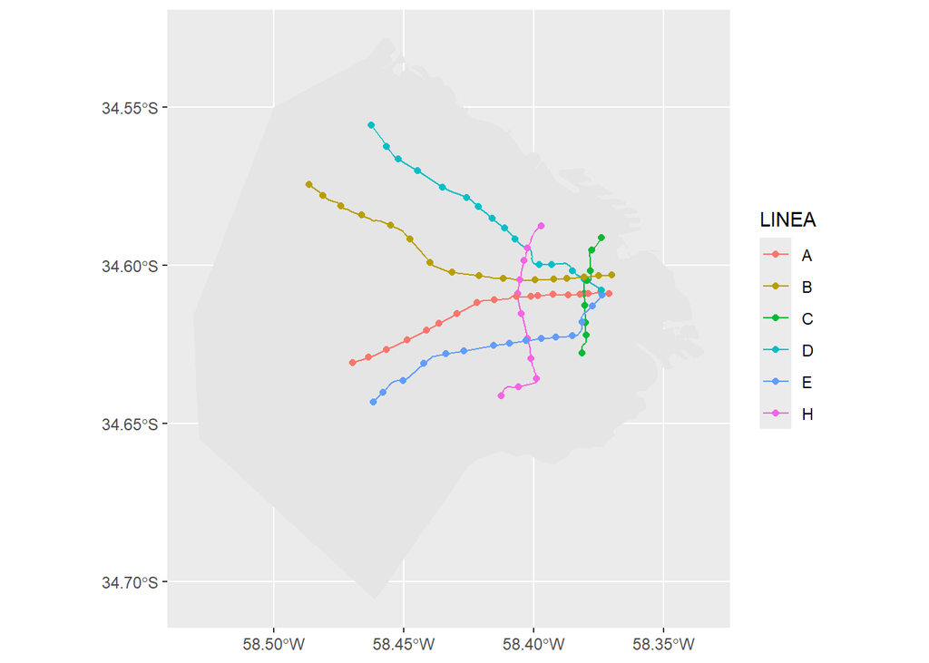

```r
ggplot() +
    geom_sf(data = radios, color = NA) +
    geom_sf(data = subte_lineas, aes(color = LINEA)) +
    geom_sf(data = subte_estaciones, aes(color = LINEA))
```

Pensando en compartir el resultado, nos queda usar `theme_void()` para un tema minimalista sin panel de fondo, y agregar título y demás textos vía `labs()`:

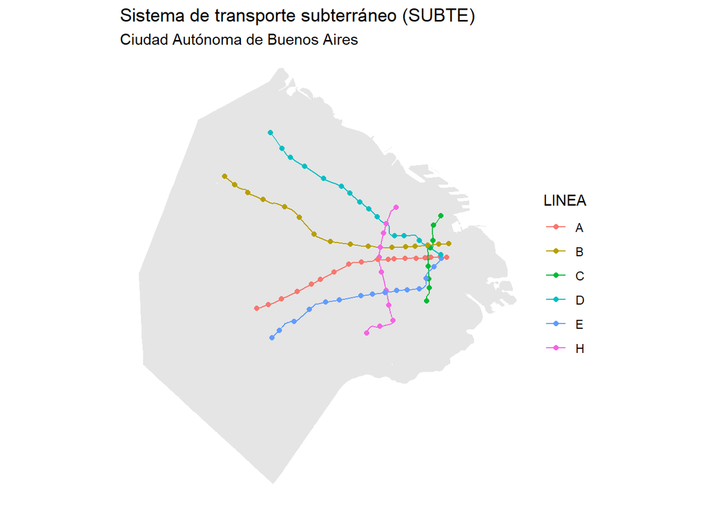

```r
ggplot() +
  geom_sf(data = radios, color = NA) +
  geom_sf(data = subte_lineas, aes(color = LINEA)) +
  geom_sf(data = subte_estaciones, aes(color = LINEA)) +
  labs(title = "Sistema de transporte subterráneo (SUBTE)",
       subtitle = "Ciudad Autónoma de Buenos Aires") +
  theme_void()
```

Este es un caso que amerita elegir los colores de la paleta de visualización a mano. Esto es porque la identidad de las líneas de SUBTE en Buenos Aires está muy asociada a su color oficial y, por lo tanto, resulta confuso verlas representadas en otra gama.

Recurriendo a `scale_color_manual()` como hicimos en una clase anterior, aquí queda el ejercicio resuelto:

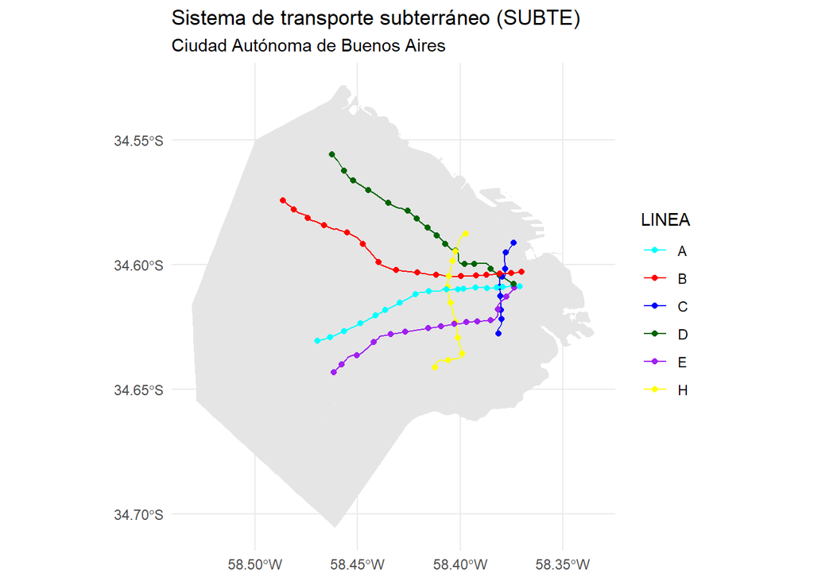

```r
color_lineas <- c("A" = "cyan", "B" = "red", "C" = "blue",
                  "D" = "darkgreen", "E" = "purple", "H" = "yellow")

ggplot() +
  geom_sf(data = radios, color = NA) +
  geom_sf(data = subte_lineas, aes(color = LINEA)) +
  geom_sf(data = subte_estaciones, aes(color = LINEA)) +
  labs(title = "Sistema de transporte subterráneo (SUBTE)",
       subtitle = "Ciudad Autónoma de Buenos Aires") +
  theme_minimal() +
  scale_color_manual(values = color_lineas)
```